# Representation & Gender Diversity in Google’s Global Workforce

## Guiding Research Question

- How does gender representation, hiring, and attrition vary across regions in Google’s workforce?

## Data Access

**Primary Data** - Region level workforce metrics such as representation, hiring, exits, and attrition. - Source: Google Diversity Report from BigQuery & data available on this Github repo. - - [Project Repository](https://github.com/PixelQuinn/Diversity-and-Inclusion-Analysis)

**Secondary Dataset:** - Self-ID Representation data, including responses related to LGBTQ+ identity and disability status. - Source: Internal Google workforce data (self-reported), accessed through Big Query. - [Project Repository](https://github.com/PixelQuinn/Diversity-and-Inclusion-Analysis).

```r
library(ggplot2)
library(tidyverse)
library(readr)
library(tidycensus)
library(janitor)
library(dplyr)
library(ggrepel)
```

## Initial Inspection

```r
# Load data
region_rep <- read_csv("data-sets/region-non-intersectional-representation.csv") %>% clean_names()
region_hire <- read_csv("data-sets/region-non-intersectional-hiring.csv") %>% clean_names()
region_exit <- read_csv("data-sets/region-non-intersectional-exits-representation.csv") %>% clean_names()
region_attr <- read_csv("data-sets/region-non-intersectional-attrition-index.csv") %>% clean_names()
glimpse(region_rep)
```

```
Rows: 24
Columns: 11
$ workforce                   <chr> "leadership", "leadership", "leadership", "leadership", "tech", "tech", "overall", "overall", "non_tech", "non_tech", "non_tech", "overall", "non_tech", "overall", "tech", "tech", "tech", "tech", "overall",…
$ report_year                 <dbl> 2021, 2022, 2021, 2022, 2022, 2021, 2022, 2021, 2022, 2021, 2021, 2021, 2022, 2022, 2021, 2022, 2022, 2021, 2021, 2022, 2022, 2021, 2021, 2022
$ region                      <chr> "APAC", "APAC", "EMEA", "EMEA", "APAC", "APAC", "APAC", "APAC", "APAC", "APAC", "EMEA", "EMEA", "EMEA", "EMEA", "EMEA", "EMEA", "AMERICAS (non-US)", "AMERICAS (non-US)", "AMERICAS (non-US)", "AMERICAS (non-…
$ race_asian                  <dbl> 0.708, 0.721, 0.066, 0.066, 0.915, 0.892, 0.888, 0.858, 0.855, 0.820, 0.105, 0.109, 0.111, 0.121, 0.113, 0.130, 0.339, 0.304, 0.218, 0.233, NA, NA, 0.147, 0.151
$ race_black_african          <dbl> NA, NA, 0.033, 0.038, 0.003, 0.004, 0.003, 0.005, 0.004, 0.005, 0.037, 0.028, 0.043, 0.032, 0.019, 0.023, 0.038, 0.032, 0.039, 0.049, NA, NA, 0.046, 0.059
$ race_hispanic_latino_latinx <dbl> NA, NA, NA, NA, 0.006, 0.007, 0.008, 0.011, 0.011, 0.016, 0.036, 0.038, 0.038, 0.039, 0.039, 0.040, 0.178, 0.192, 0.333, 0.341, 0.409, 0.438, 0.450, 0.470
$ race_indigenous             <dbl> NA, NA, NA, NA, 0.001, NA, 0.002, 0.002, 0.002, 0.003, 0.004, 0.003, 0.004, 0.003, 0.003, 0.003, 0.007, 0.008, 0.010, 0.008, NA, NA, 0.012, 0.009
$ race_mena                   <dbl> NA, NA, 0.045, 0.058, 0.004, 0.005, 0.005, 0.006, 0.006, 0.007, 0.067, 0.073, 0.069, 0.078, 0.079, 0.085, 0.063, 0.065, 0.048, 0.047, NA, NA, 0.033, 0.035
$ race_white_european         <dbl> 0.288, 0.279, 0.877, 0.858, 0.084, 0.106, 0.110, 0.138, 0.141, 0.173, 0.803, 0.804, 0.786, 0.781, 0.805, 0.777, 0.462, 0.501, 0.482, 0.436, 0.523, 0.500, 0.467, 0.416
$ gender_women                <dbl> 0.292, 0.318, 0.269, 0.297, 0.235, 0.225, 0.353, 0.346, 0.453, 0.443, 0.444, 0.327, 0.454, 0.338, 0.210, 0.227, 0.235, 0.204, 0.310, 0.334, 0.343, 0.298, 0.397, 0.405
$ gender_men                  <dbl> 0.708, 0.682, 0.731, 0.703, 0.765, 0.775, 0.647, 0.654, 0.547, 0.557, 0.556, 0.673, 0.546, 0.662, 0.790, 0.773, 0.765, 0.796, 0.690, 0.666, 0.657, 0.702, 0.603, 0.595
```

```r
summary(region_rep)
```

```
  workforce          report_year      region            race_asian     race_black_african race_hispanic_latino_latinx race_indigenous      race_mena       race_white_european  gender_women      gender_men
 Length:24          Min.   :2021   Length:24          Min.   :0.0660   Min.   :0.00300    Min.   :0.00600             Min.   :0.001000   Min.   :0.00400   Min.   :0.0840      Min.   :0.2040   Min.   :0.5460
 Class :character   1st Qu.:2021   Class :character   1st Qu.:0.1150   1st Qu.:0.00500    1st Qu.:0.01475             1st Qu.:0.003000   1st Qu.:0.00675   1st Qu.:0.2525      1st Qu.:0.2605   1st Qu.:0.6360
 Mode  :character   Median :2022   Mode  :character   Median :0.2255   Median :0.03200    Median :0.03900             Median :0.003000   Median :0.04750   Median :0.4745      Median :0.3225   Median :0.6775
                    Mean   :2022                      Mean   :0.4032   Mean   :0.02700    Mean   :0.15500             Mean   :0.004941   Mean   :0.04390   Mean   :0.4832      Mean   :0.3232   Mean   :0.6768
                    3rd Qu.:2022                      3rd Qu.:0.7953   3rd Qu.:0.03825    3rd Qu.:0.33500             3rd Qu.:0.008000   3rd Qu.:0.06750   3rd Qu.:0.7823      3rd Qu.:0.3640   3rd Qu.:0.7395
                    Max.   :2022                      Max.   :0.9150   Max.   :0.05900    Max.   :0.47000             Max.   :0.012000   Max.   :0.08500   Max.   :0.8770      Max.   :0.4540   Max.   :0.7960
                                                      NA's   :2        NA's   :4          NA's   :4                   NA's   :7          NA's   :4
```

```r
self_ID <- read_csv("data-sets/selfid-representation.csv")
glimpse(self_ID)
```

```
Rows: 16
Columns: 3
$ workforce   <chr> "selfid_lgbtq", "selfid_lgbtq", "selfid_lgbtq", "selfid_lgbtq", "selfid_disability", "selfid_disability", "selfid_disability", "selfid_disability", "selfid_military", "selfid_military", "selfid_military", "selfid_military"…
$ report_year <dbl> 2019, 2020, 2021, 2022, 2019, 2020, 2021, 2022, 2019, 2020, 2021, 2022, 2019, 2020, 2021, 2022
$ global      <dbl> 0.085, 0.071, 0.069, 0.067, 0.075, 0.061, 0.056, 0.054, 0.052, 0.055, 0.052, 0.050, NA, NA, NA, NA
```

```r
# Join the representation and hiring by region, year, and workforce type.

gender_rep_hiring <- region_rep %>%
  inner_join(region_hire, by = c("region", "report_year", "workforce"), suffix = c("_rep", "_hire"))
```

```r
gender_rep_hiring %>%
  filter(!is.na(gender_women_rep), !is.na(gender_women_hire)) %>%
  group_by(region) %>%
  summarise(
    avg_rep_women = mean(gender_women_rep),
    avg_hire_women = mean(gender_women_hire)
  )
```

| region | avg_rep_women | avg_hire_women |
| --- | --- | --- |
| AMERICAS (non-US) | 0.3141667 | 0.315500 |
| APAC | 0.3331250 | 0.327375 |
| EMEA | 0.3207500 | 0.365375 |

```r
# Define a function to label representation as "High" or "Low"
label_rep_level <- function(pct) {
  if (is.na(pct)) {
    return(NA)
  } else if (pct > 0.5) {
    return("High")
  } else {
    return("Low")
  }
}

# Apply the function to create a new label
region_rep <- region_rep %>%
  mutate(women_rep_label = sapply(gender_women, label_rep_level))
```

```r
# Convert race columns into long format for later visualization.

race_long_format <- region_rep %>%
  pivot_longer(cols = starts_with("race_"),
               names_to = "race_group",
               values_to = "proportion")
```

```r
glimpse(race_long_format)
```

```
Rows: 144
Columns: 8
$ workforce       <chr> "leadership", "leadership", "leadership", "leadership", "leadership", "leadership", "leadership", "leadership", "leadership", "leadership", "leadership", "leadership", "leadership", "leadership", "leadership", "leaders…
$ report_year     <dbl> 2021, 2021, 2021, 2021, 2021, 2021, 2022, 2022, 2022, 2022, 2022, 2022, 2021, 2021, 2021, 2021, 2021, 2021, 2022, 2022, 2022, 2022, 2022, 2022, 2022, 2022, 2022, 2022, 2022, 2022, 2021, 2021, 2021, 2021, 2021, 2021, 20…
$ region          <chr> "APAC", "APAC", "APAC", "APAC", "APAC", "APAC", "APAC", "APAC", "APAC", "APAC", "APAC", "APAC", "EMEA", "EMEA", "EMEA", "EMEA", "EMEA", "EMEA", "EMEA", "EMEA", "EMEA", "EMEA", "EMEA", "EMEA", "APAC", "APAC", "APAC", "A…
$ gender_women    <dbl> 0.292, 0.292, 0.292, 0.292, 0.292, 0.292, 0.318, 0.318, 0.318, 0.318, 0.318, 0.318, 0.269, 0.269, 0.269, 0.269, 0.269, 0.269, 0.297, 0.297, 0.297, 0.297, 0.297, 0.297, 0.235, 0.235, 0.235, 0.235, 0.235, 0.235, 0.225, 0…
$ gender_men      <dbl> 0.708, 0.708, 0.708, 0.708, 0.708, 0.708, 0.682, 0.682, 0.682, 0.682, 0.682, 0.682, 0.731, 0.731, 0.731, 0.731, 0.731, 0.731, 0.703, 0.703, 0.703, 0.703, 0.703, 0.703, 0.765, 0.765, 0.765, 0.765, 0.765, 0.765, 0.775, 0…
$ women_rep_label <chr> "Low", "Low", "Low", "Low", "Low", "Low", "Low", "Low", "Low", "Low", "Low", "Low", "Low", "Low", "Low", "Low", "Low", "Low", "Low", "Low", "Low", "Low", "Low", "Low", "Low", "Low", "Low", "Low", "Low", "Low", "Low", "…
$ race_group      <chr> "race_asian", "race_black_african", "race_hispanic_latino_latinx", "race_indigenous", "race_mena", "race_white_european", "race_asian", "race_black_african", "race_hispanic_latino_latinx", "race_indigenous", "race_mena…
$ proportion      <dbl> 0.708, NA, NA, NA, NA, 0.288, 0.721, NA, NA, NA, NA, 0.279, 0.066, 0.033, NA, NA, 0.045, 0.877, 0.066, 0.038, NA, NA, 0.058, 0.858, 0.915, 0.003, 0.006, 0.001, 0.004, 0.084, 0.892, 0.004, 0.007, NA, 0.005, 0.106, 0.888…
```

```r
# Calculate average attrition per gender by region.

region_attr %>%
  group_by(region) %>%
  summarise(
    avg_attr_women = mean(gender_women, na.rm = TRUE),
    avg_attr_men = mean(gender_men, na.rm = TRUE)
  )
```

| region | avg_attr_women | avg_attr_men |
| --- | --- | --- |
| AMERICAS (non-US) | 78.40000 | 110.0000 |
| APAC | 83.66667 | 107.5000 |
| EMEA | 90.83333 | 105.3333 |

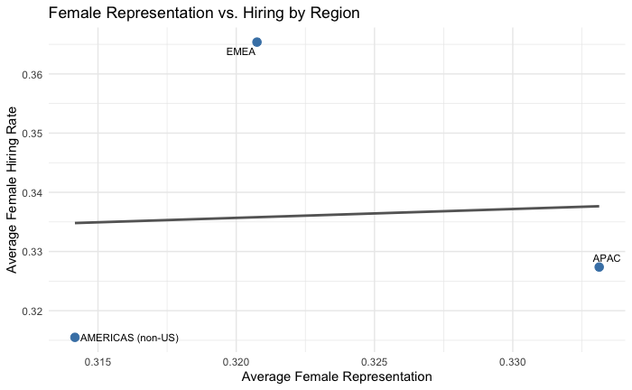

```r
gender_rep_hiring %>%
  filter(!is.na(gender_women_rep), !is.na(gender_women_hire)) %>%
  group_by(region) %>%
  summarise(
    avg_rep = mean(gender_women_rep),
    avg_hire = mean(gender_women_hire)
  ) %>%
  ggplot(aes(x = avg_rep, y = avg_hire)) +
  geom_point(color = "steelblue", size = 3) +
  geom_smooth(method = "lm", se = FALSE, color = "gray40") +
  geom_text_repel(aes(label = region), size = 3) +
  labs(
    title = "Female Representation vs. Hiring by Region",
    x = "Average Female Representation",
    y = "Average Female Hiring Rate"
  ) +
  theme_minimal()
```

## Insights:

- A regression line is added to show overall correlation.
- EMEA is out performing The Americas and APAC.
- We see Americas and APAC under the trend line.
- This shows female hiring rates in these areas are lagging behind.
- All three are below the soft 50% cap.

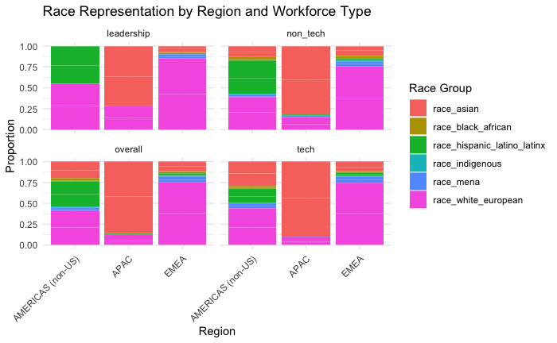

```r
race_long_format %>%
  filter(!is.na(proportion)) %>%
  group_by(region, workforce) %>%
  mutate(norm_prop = proportion / sum(proportion, na.rm = TRUE)) %>%
  ggplot(aes(x = region, y = norm_prop, fill = race_group)) +
  geom_bar(stat = "identity", position = "stack") +
  facet_wrap(~ workforce) +
  labs(
    title = "Race Representation by Region and Workforce Type",
    x = "Region",
    y = "Proportion",
    fill = "Race Group"
  ) +
  theme_minimal() +
  theme(axis.text.x = element_text(angle = 45, hjust = 1))
```

```r
# Had to add the mutate to normalize to proper percentage...
```

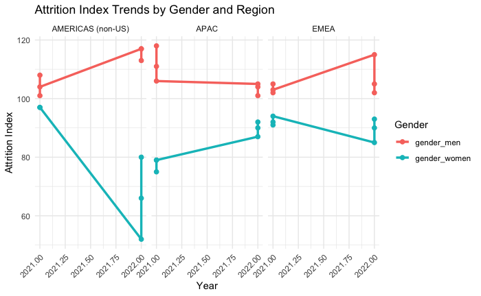

```r
region_attr %>%
  pivot_longer(cols = starts_with("gender_"), names_to = "gender", values_to = "attrition_index") %>%
  ggplot(aes(x = report_year, y = attrition_index, color = gender, group = gender)) +
  geom_line(size = 1.2) +
  geom_point(size = 2) +
  facet_wrap(~ region) +
  labs(
    title = "Attrition Index Trends by Gender and Region",
    x = "Year",
    y = "Attrition Index",
    color = "Gender"
  ) +
  theme_minimal() +
  theme(axis.text.x = element_text(angle = 45, hjust = 1))
```

## Insights:

- Across all regions, men consistently exhibit higher attrition index scores than woman.
- The gap between genders is widest in The Americas.
- APAC shows relatively stable attrition gaps overtime.
- EMEA’s male attrition spiked pretty high in 2022, widening the gap.

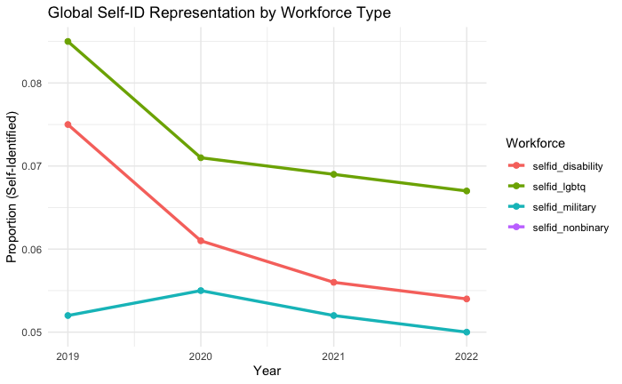

```r
## Plotting the Global Self-ID. to find insights on these demographics.

ggplot(self_ID, aes(x = report_year, y = global, color = workforce, group = workforce)) +
  geom_line(size = 1.2) +
  geom_point(size = 2) +
  labs(
    title = "Global Self-ID Representation by Workforce Type",
    x = "Year",
    y = "Proportion (Self-Identified)",
    color = "Workforce"
  ) +
  theme_minimal()
```

## Insights:

- Self-identification rates have generally declined across all groups overall.
- LGBTQ+ employees made up the highest self-ID group in 2019 and kept this lead, even after decline.
- The drop could be a change in reporting practices, cultural stigma, or workforce demographic shifts.
- This trend shows the importance of psychological safety and transparent communication on Self-ID in the workplace.

```r
# Basic linear regression model
attrition_model <- lm(attrition_index ~ gender + region, data = region_attr %>%
                         pivot_longer(cols = starts_with("gender_"), names_to = "gender", values_to = "attrition_index"))

# View model summary
summary(attrition_model)
```

```
Call:
lm(formula = attrition_index ~ gender + region, data = region_attr %>%
    pivot_longer(cols = starts_with("gender_"), names_to = "gender",
        values_to = "attrition_index"))

Residuals:
    Min      1Q  Median      3Q     Max
-31.062  -5.057  -1.109   6.193  13.938

Coefficients:
                   Estimate Std. Error t value Pr(>|t|)
(Intercept)        106.1146     3.2117  33.040  < 2e-16 ***
gendergender_women -23.0521     3.2117  -7.177 4.54e-08 ***
regionAPAC           0.9948     3.9632   0.251    0.803
regionEMEA           3.4948     3.9632   0.882    0.385
---
Signif. codes:  0 ‘***’ 0.001 ‘**’ 0.01 ‘*’ 0.05 ‘.’ 0.1 ‘ ’ 1

Residual standard error: 9.488 on 31 degrees of freedom
  (1 observation deleted due to missingness)
Multiple R-squared:  0.6267,    Adjusted R-squared:  0.5906
F-statistic: 17.35 on 3 and 31 DF,  p-value: 8.515e-07
```

```r
# Expanding the basic model
# Prepare dataset
attrition_data <- region_attr %>%
  pivot_longer(cols = starts_with("gender_"), names_to = "gender", values_to = "attrition_index") %>%
  left_join(region_rep, by = c("region", "report_year", "workforce")) %>%
  mutate(workforce = as.factor(workforce),
         region = as.factor(region),
         gender = as.factor(gender))

# Fit model
attrition_model_v2 <- lm(attrition_index ~ gender + region + workforce + report_year, data = attrition_data)

# Summary
summary(attrition_model_v2)
```

```
Call:
lm(formula = attrition_index ~ gender + region + workforce +
    report_year, data = attrition_data)

Residuals:
    Min      1Q  Median      3Q     Max
-28.008  -5.130   0.750   5.815  13.862

Coefficients:
                   Estimate Std. Error t value Pr(>|t|)
(Intercept)        3438.514   6688.294   0.514    0.611
gendergender_women  -23.130      3.309  -6.991 1.33e-07 ***
regionAPAC            1.112      4.086   0.272    0.787
regionEMEA            3.612      4.086   0.884    0.384
workforceoverall     -2.000      3.984  -0.502    0.620
workforcetech        -4.112      4.086  -1.006    0.323
report_year          -1.648      3.309  -0.498    0.622
---
Signif. codes:  0 ‘***’ 0.001 ‘**’ 0.01 ‘*’ 0.05 ‘.’ 0.1 ‘ ’ 1

Residual standard error: 9.759 on 28 degrees of freedom
  (1 observation deleted due to missingness)
Multiple R-squared:  0.6433,    Adjusted R-squared:  0.5669
F-statistic: 8.418 on 6 and 28 DF,  p-value: 2.881e-05
```

## Machine Learning Model Insights:

- An expanded linear regression model was built to predict attrition index based on gender, region, workforce type, and report year.
- The model explained approximately 64% of the variance in attrition index, suggesting a moderately strong fit.
- The analysis revealed that gender remains a highly significant predictor.
- Women had a 23 point lower attrition index compared to men, even after accounting for regional, workforce, and time differences.
- No other factors (region, workforce, or year) showed statistically significant predictive power in this model.
- These results reinforce the critical need to consider gender dynamics in retention strategies.
- However, additional variables such as tenure, compensation, and job level may further improve predictive power in future modeling efforts.

## Key Insights and Analysis

These findings highlight systemic gaps in workplace diversity and inclusion across regions and identity groups. They also suggest that gender specific retention strategies may be the most immediate opportunity for improving workforce equity.

## Recommendations

Based on the findings, several actions are recommended for organizational leadership:

- **Targeted Recruitment Initiatives**: Increase recruitment efforts for women in APAC and the Americas regions to close the gender hiring gap.
- **Leadership Development for Underrepresented Groups**: Invest in career advancement programs specifically for Black, Hispanic/Latinx, Indigenous, and MENA employees.
- **Enhance Psychological Safety**: Implement training and communication strategies to encourage safe, voluntary self-identification among employees.
- **Advanced Attrition Modeling**: Future workforce studies should include variables such as tenure, job level, salary, and performance scores to better predict retention risks.